# Métodos Cuantitativos en Ecología - MCE5

EXAMEN FINAL - 2022II

Chacón Alisson

2023-07-24

Los contenidos de esta evaluación corresponden a los temas:

- GLM y GAM
- Introducción a estadística Bayesiana
- Series de tiempo
- Análisis espacial

Ustedes estan utilizando un archivo tipo R Markdown (`.Rmd`). Las instruciones son **[1 PUNTO]**:

- Bifurquen el repositorio en GitHub y clonen en su computador usando un proyecto con control de la versión de RStudio.
- Arriba, donde dice “author”, deben llenar sus nombres.
- **Todo resultado debe ir con su explicación y/o discusión, caso contrario no se calificará.**
- **NO IMPRIMA los datos o tablas completas**, reporte únicamente figuras o tablas resumen. Si tiene varias figuras use la función `ggarrange` de la librería `ggpubr`.
- Al final de este examen deben utilizar el comando “Knit” para generar un archivo HTML.
- **Cada pregunta debe tener al menos un cntrol de la versión**.
- Su entrega consiste en colocar el **enlace de GitHub** en la actividad “ExamenFinal”.

## **PREGUNTA 1: GLM, GAM y Regresión Bayesiana [3 PUNTOS]**

En el archivo `"glm.xlsx"` tiene tres datos:

- aedes: insecticidas utilizados para controlar el número de mosquitos en un experimento. Cada vez que se repite la aplicación del insecticida parece disminuir la cantidad de zancudos vivos.
- leishmania: en una infección con leishmania cuando se analiza el tejido qué sucede con la concentración de algunas células y si están o no afectadas.
- disease: cómo la edad afecta a diferentes características dicotómicas.

Realice los siguientes análisis:

Realizar los siguientes análisis y respectivas interpretaciones:

1. Análisis exploratorio.
2. Planteamiento de hipótesis.
3. Análisis de regresión
4. Planteamiento del modelo.
5. Validez del modelo.

```r
# Cargar paquetes necesarios
library(stats)
library(graphics)
library(MASS)
library(readxl)
# Cargar el archivo de datos - Hoja "aedes"
data_aedes <- read_xlsx("glm.xlsx", sheet = "aedes")

# Análisis exploratorio para aedes
summary(data_aedes$aedes)  # Resumen estadístico de la variable aedes
```

```
##    Min. 1st Qu.  Median    Mean 3rd Qu.    Max.
##    44.0   136.5   523.5   865.4  1217.8  3020.0
```

```r
# Planteamiento de hipótesis para aedes
cat("Hipótesis para aedes: Cada vez que se repite la aplicación del insecticida, la cantidad de zancudos vivos disminuye.\n\n")
```

```
## Hipótesis para aedes: Cada vez que se repite la aplicación del insecticida, la cantidad de zancudos vivos disminuye.
```

```r
# Análisis de regresión para aedes
glm_aedes <- glm(aedes ~ repetition, family = poisson(link = "log"), data = data_aedes)
summary(glm_aedes)  # Resumen del modelo de regresión para aedes
```

```
##
## Call:
## glm(formula = aedes ~ repetition, family = poisson(link = "log"),
##     data = data_aedes)
##
## Deviance Residuals:
##    Min      1Q  Median      3Q     Max
## -38.62  -30.47  -12.18   12.71   54.42
##
## Coefficients:
##             Estimate Std. Error z value Pr(>|z|)
## (Intercept) 6.669058   0.014414 462.677  < 2e-16 ***
## repetition  0.026590   0.003636   7.312 2.63e-13 ***
## ---
## Signif. codes:  0 '***' 0.001 '**' 0.01 '*' 0.05 '.' 0.1 ' ' 1
##
## (Dispersion parameter for poisson family taken to be 1)
##
##     Null deviance: 26631  on 29  degrees of freedom
## Residual deviance: 26577  on 28  degrees of freedom
## AIC: 26819
##
## Number of Fisher Scoring iterations: 5
```

## **PREGUNTA 2: Series de tiempo [3 PUNTOS]**

En el archivo `"ts.xlsx"` tiene tres datos:

- quakes: cantidad de eventos de terremotos por cada año.
- hepatitis: casos de hepatitis por mes entre 2010 y 2017 (acomodar la tabla si es necesario)
- wildfire: cantidad de eventos de incendios forestales por mes entre 2003 y 2017.

Realizar los siguientes análisis y respectivas interpretaciones:

1. Análisis exploratorio: autocorrelación y descomposición, análisis estacional.
2. ARIMA, SARIMA, ETS, NNAR
3. Validez de los modelos.
4. Predicción a 20 años o a 24 meses según corresponda.

```r
# Cargar paquetes necesarios
library(readxl)
library(forecast)
```

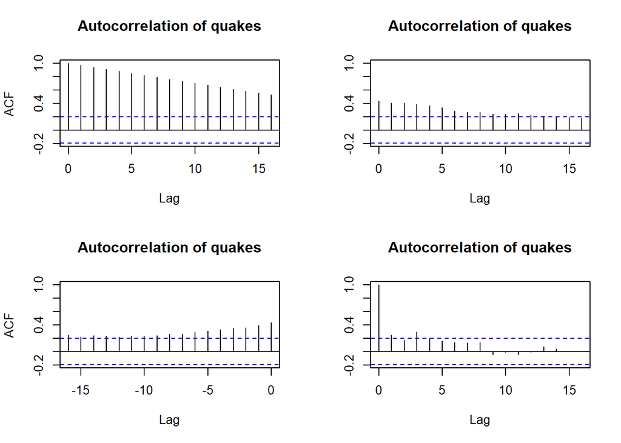

```r
library(ggplot2)
# Cargar el archivo de datos - Hoja "quakes"
data_quakes <- read_excel("ts.xlsx", sheet = "quakes")

# Obtener los datos de la columna "quakes"
quakes <- data_quakes$quakes

# Convertir los datos en una serie de tiempo
ts_quakes <- ts(data_quakes, start = c(2000, 1), frequency = 1)

# Análisis exploratorio para la serie "quakes"
# Autocorrelación
acf(ts_quakes, main = "Autocorrelation of quakes")
```

```r
# Intentar realizar la descomposición
tryCatch(
  {
    decomposed_quakes <- decompose(ts_quakes)
    # Si se realiza la descomposición con éxito, mostrar los resultados
    plot(decomposed_quakes)
  },
  error = function(e) {
    # Si ocurre un error, mostrar un mensaje de alerta explicando la razón
    cat("No es posible realizar la descomposición de la serie de tiempo 'quakes' debido a la falta de períodos suficientes.\n")
  }
)
```

```
## No es posible realizar la descomposición de la serie de tiempo 'quakes' debido a la falta de períodos suficientes.
```

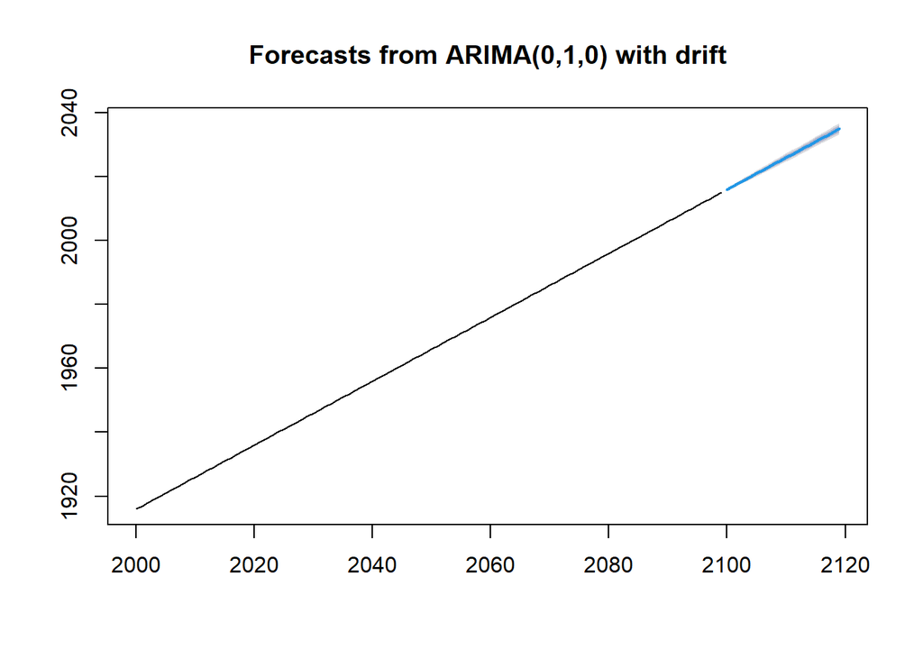

```r
# Modelos de pronóstico (ARIMA, SARIMA, ETS)
# Modelos de pronóstico (ARIMA, SARIMA, ETS)
model_arima_quakes <- auto.arima(ts_quakes[, 1])
model_sarima_quakes <- auto.arima(ts_quakes[, 1], seasonal = TRUE)
model_ets_quakes <- ets(ts_quakes[, 1])

# Validez de los modelos

# Predicción a 20 años
forecast_arima_quakes <- forecast(model_arima_quakes, h = 20)
forecast_sarima_quakes <- forecast(model_sarima_quakes, h = 20)
forecast_ets_quakes <- forecast(model_ets_quakes, h = 20)

# Visualización de los resultados
plot(forecast_arima_quakes)
plot(forecast_sarima_quakes)
```

[output not shown]

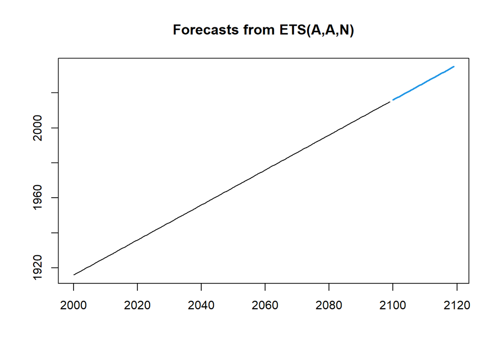

```r
plot(forecast_ets_quakes)
```

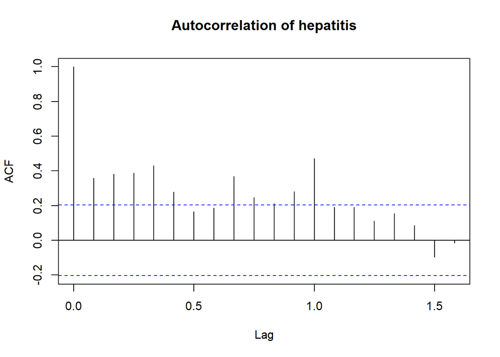

```r
# Cargar paquetes necesarios
library(readxl)
library(forecast)
library(ggplot2)

# Cargar el archivo de datos - Hoja "hepatitis"
data_hepatitis <- read_excel("ts.xlsx", sheet = "hepatitis")
# Acomodar la tabla si es necesario (asumiendo que los datos están en columnas)
hepatitis_matrix <- as.matrix(data_hepatitis[, -1])

# Convertir la matriz en una serie de tiempo univariada
ts_hepatitis_univar <- ts(as.vector(hepatitis_matrix), start = c(2010, 1), frequency = 12)

# Eliminar los datos vacíos (enero a febrero de 2010, noviembre a diciembre de 2017)
ts_hepatitis_clean <- window(ts_hepatitis_univar, start = c(2010, 3), end = c(2017, 10))

# Análisis exploratorio para la serie "Hepatitis"
# Autocorrelación
acf(ts_hepatitis_clean, main = "Autocorrelation of hepatitis")
```

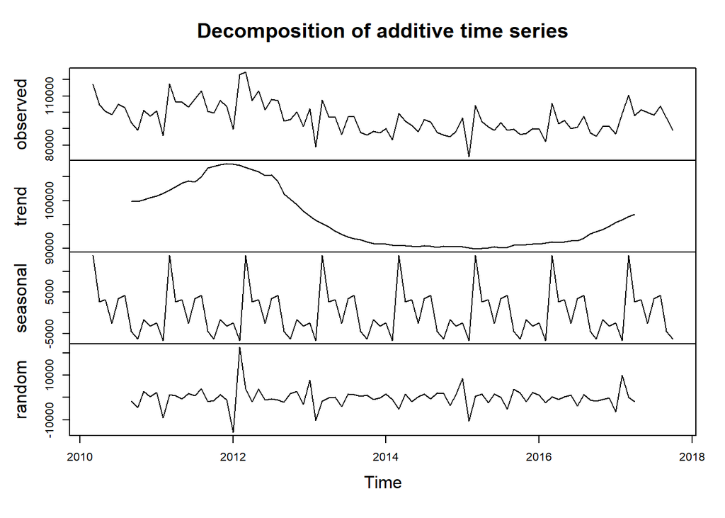

```r
# Descomposición
decomposed_hepatitis <- decompose(ts_hepatitis_clean)
plot(decomposed_hepatitis)
```

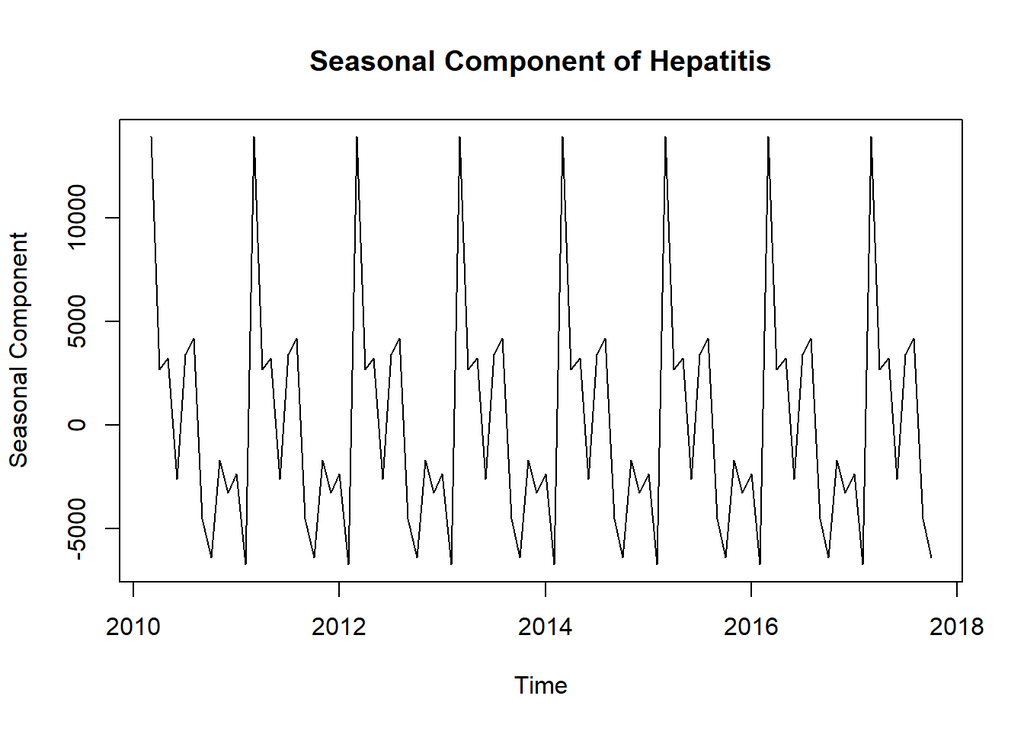

```r
# Análisis estacional
seasonal_decomposition <- decompose(ts_hepatitis_clean)
seasonal_component <- seasonal_decomposition$seasonal
plot(seasonal_component, main = "Seasonal Component of Hepatitis", xlab = "Time", ylab = "Seasonal Component")
```

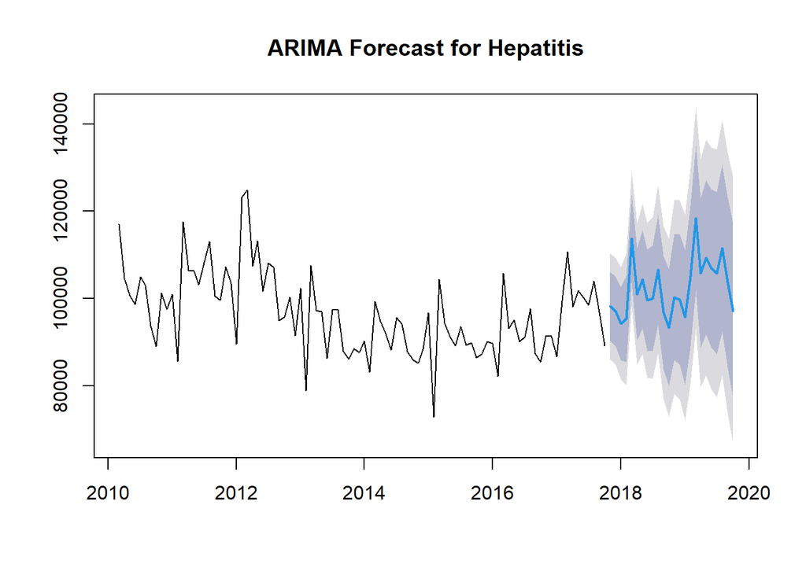

```r
# Ajustar modelos ARIMA, SARIMA, ETS y NNAR
model_arima_hepatitis <- auto.arima(ts_hepatitis_clean)
model_sarima_hepatitis <- auto.arima(ts_hepatitis_clean, seasonal = TRUE)
model_ets_hepatitis <- ets(ts_hepatitis_clean)
model_nnar_hepatitis <- nnetar(ts_hepatitis_clean)

# Predicción a 24 meses
forecast_arima_hepatitis <- forecast(model_arima_hepatitis, h = 24)
forecast_sarima_hepatitis <- forecast(model_sarima_hepatitis, h = 24)
forecast_ets_hepatitis <- forecast(model_ets_hepatitis, h = 24)
forecast_nnar_hepatitis <- forecast(model_nnar_hepatitis, h = 24)

# Visualización de los resultados (gráficos individuales)
plot(forecast_arima_hepatitis, main = "ARIMA Forecast for Hepatitis")
```

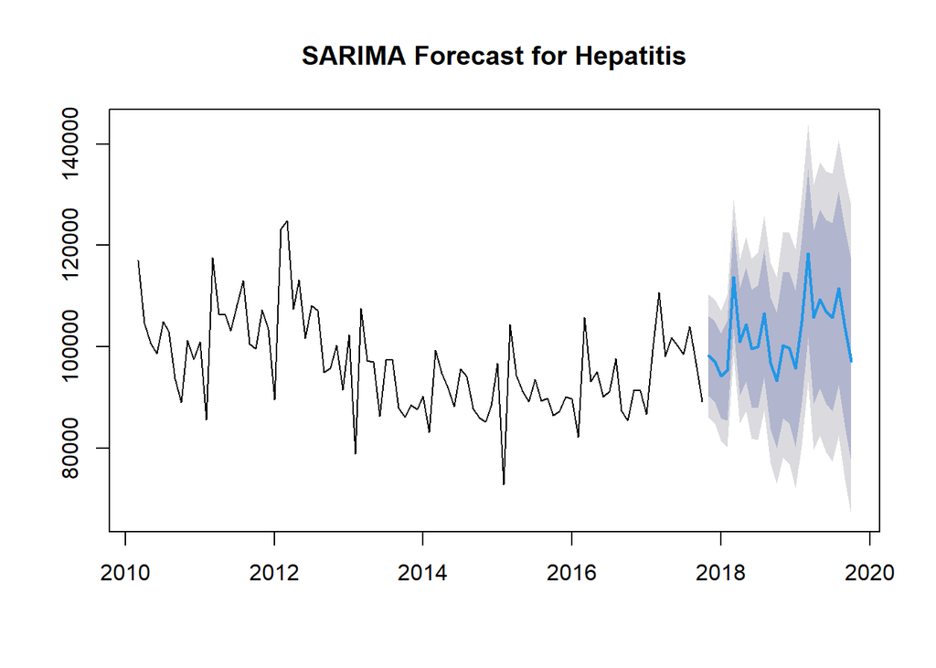

```r
plot(forecast_sarima_hepatitis, main = "SARIMA Forecast for Hepatitis")
```

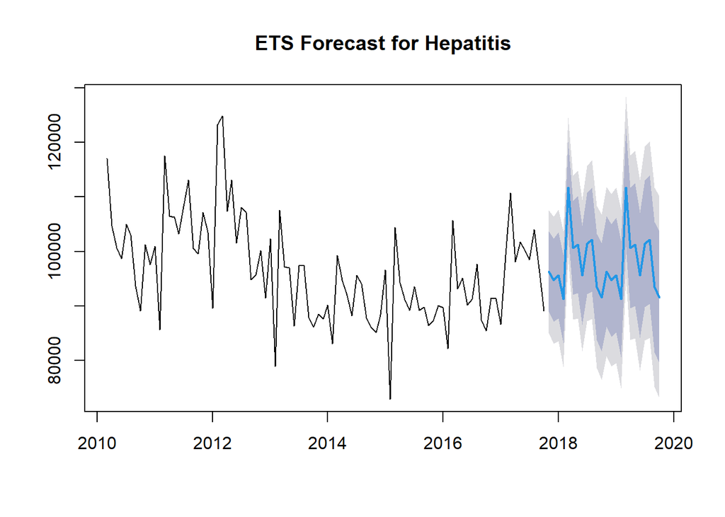

```r
plot(forecast_ets_hepatitis, main = "ETS Forecast for Hepatitis")
```

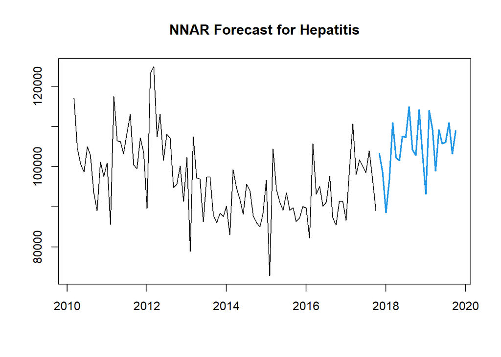

```r
plot(forecast_nnar_hepatitis, main = "NNAR Forecast for Hepatitis")
```

```r
# Obtener los valores de AIC para ARIMA, SARIMA y ETS
AIC_arima <- AIC(model_arima_hepatitis)
AIC_sarima <- AIC(model_sarima_hepatitis)
AIC_ets <- AIC(model_ets_hepatitis)

# Obtener el valor de AIC para NNAR (calculado manualmente)
n <- length(ts_hepatitis_clean)
k_nnar <- length(coef(model_nnar_hepatitis))
mse_nnar <- mean(residuals(model_nnar_hepatitis)^2)
AIC_nnar <- n * log(mse_nnar) + 2 * k_nnar

# Imprimir los valores de AIC para cada modelo
print(paste("AIC ARIMA:", AIC_arima))
```

```
## [1] "AIC ARIMA: 1618.05269302044"
```

```r
print(paste("AIC SARIMA:", AIC_sarima))
```

```
## [1] "AIC SARIMA: 1618.05269302044"
```

```r
print(paste("AIC ETS:", AIC_ets))
```

```
## [1] "AIC ETS: 2023.53956293472"
```

```r
print(paste("AIC NNAR:", AIC_nnar))
```

```
## [1] "AIC NNAR: NA"
```

```r
# Determinar el mejor modelo
mejor_modelo <- which.min(c(AIC_arima, AIC_sarima, AIC_ets, AIC_nnar))

# Imprimir el nombre del mejor modelo seleccionado
if (mejor_modelo == 1) {
  modelo_seleccionado <- model_arima_hepatitis
  metodo <- "ARIMA"
} else if (mejor_modelo == 2) {
  modelo_seleccionado <- model_sarima_hepatitis
  metodo <- "SARIMA"
} else if (mejor_modelo == 3) {
  modelo_seleccionado <- model_ets_hepatitis
  metodo <- "ETS"
} else {
  modelo_seleccionado <- model_nnar_hepatitis
  metodo <- "NNAR"
}

print(paste("Mejor modelo seleccionado:", metodo))
```

```
## [1] "Mejor modelo seleccionado: ARIMA"
```

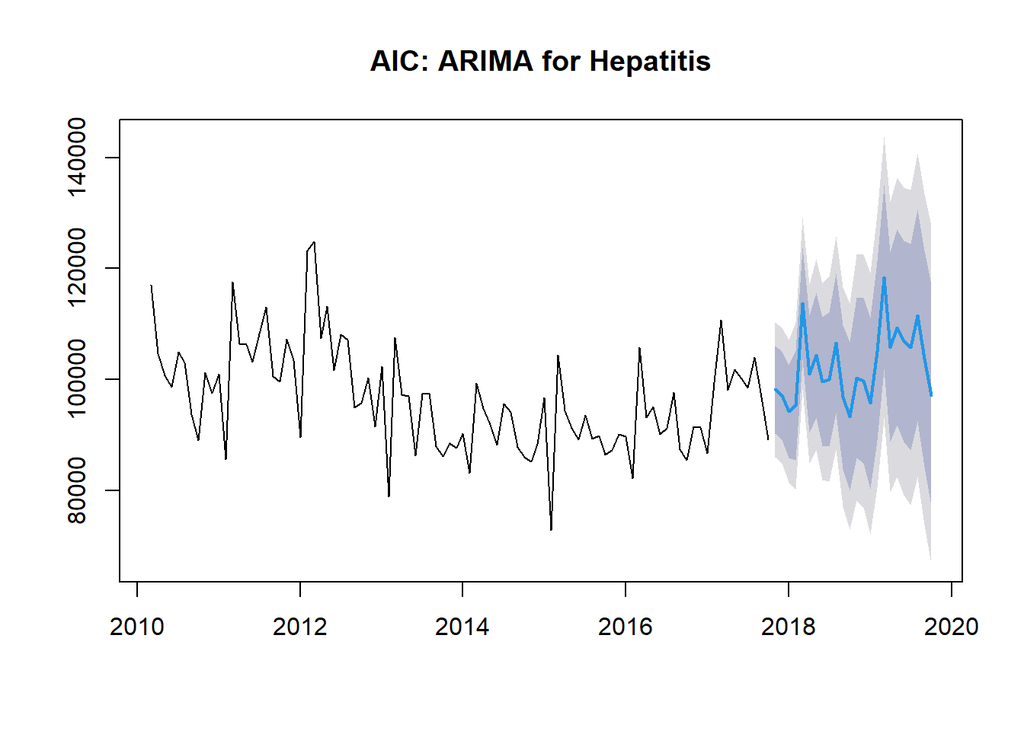

```r
# Predicción a 24 meses con el mejor modelo seleccionado
forecast_modelo_seleccionado <- forecast(modelo_seleccionado, h = 24)

# Visualización de los resultados (gráfico de la predicción del mejor modelo)
plot(forecast_modelo_seleccionado, main = paste("AIC:", metodo, "for Hepatitis"))
```

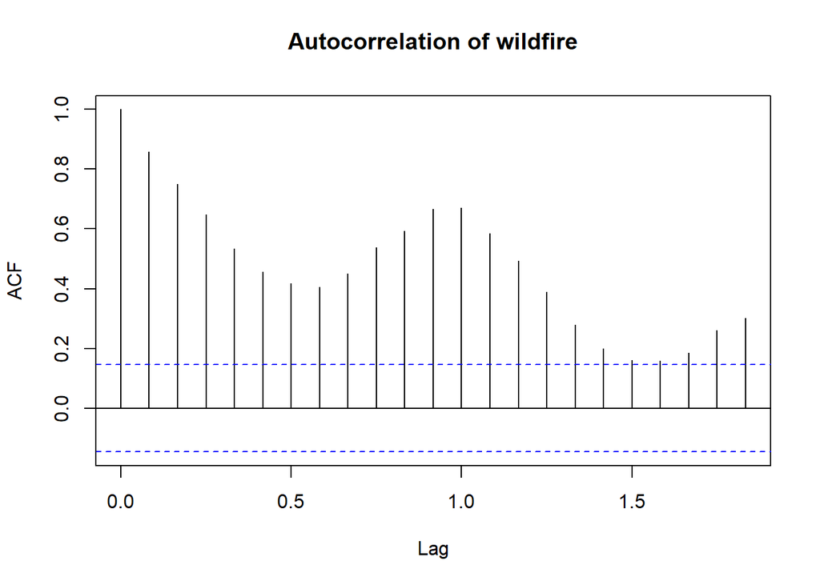

```r
# Cargar paquetes necesarios
library(readxl)
library(forecast)
library(ggplot2)

# Cargar el archivo de datos - Hoja "wildfire"
data_wildfire <- read_excel("ts.xlsx", sheet = "wildfire")

# Convertir los datos en una serie de tiempo
ts_wildfire <- ts(data_wildfire$`Fire frequency`, start = c(2003, 1), frequency = 12)

# Análisis exploratorio para la serie "wildfire"
# Autocorrelación
acf(ts_wildfire, main = "Autocorrelation of wildfire")
```

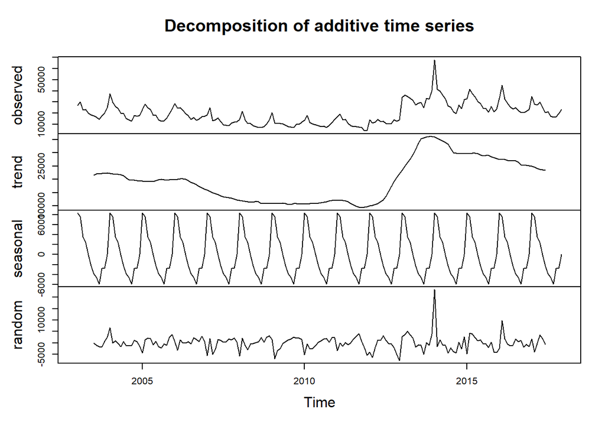

```r
# Descomposición
decomposed_wildfire <- decompose(ts_wildfire)
plot(decomposed_wildfire)
```

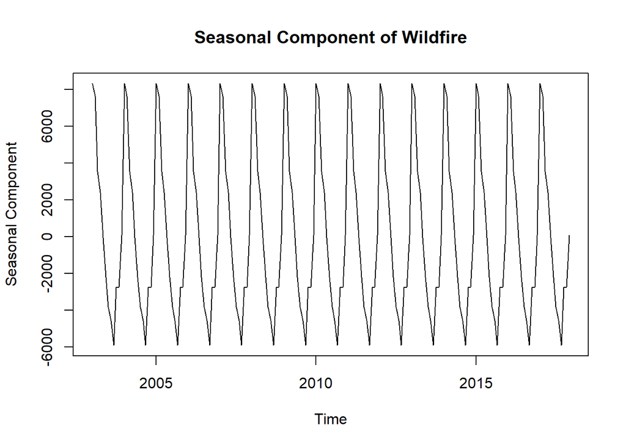

```r
# Análisis estacional
seasonal_decomposition <- decompose(ts_wildfire)
seasonal_component <- seasonal_decomposition$seasonal
plot(seasonal_component, main = "Seasonal Component of Wildfire", xlab = "Time", ylab = "Seasonal Component")
```

```r
# Ajustar modelos ARIMA, SARIMA, ETS y NNAR
model_arima_wildfire <- auto.arima(ts_wildfire)
model_sarima_wildfire <- auto.arima(ts_wildfire, seasonal = TRUE)
model_ets_wildfire <- ets(ts_wildfire)
model_nnar_wildfire <- nnetar(ts_wildfire)

# Validez de los modelos
accuracy(model_arima_wildfire)
```

```
##                    ME     RMSE      MAE       MPE     MAPE      MASE
## Training set 2.940338 4049.337 2521.978 -1.947937 12.80528 0.5438864
##                       ACF1
## Training set -0.0005355625
```

```r
accuracy(model_sarima_wildfire)
```

```
##                    ME     RMSE      MAE       MPE     MAPE      MASE
## Training set 2.940338 4049.337 2521.978 -1.947937 12.80528 0.5438864
##                       ACF1
## Training set -0.0005355625
```

```r
accuracy(model_ets_wildfire)
```

```
##                     ME     RMSE      MAE       MPE    MAPE      MASE
## Training set -43.62402 3481.734 2242.889 -1.698047 11.4254 0.4836984
##                     ACF1
## Training set -0.01552813
```

```r
accuracy(model_nnar_wildfire)
```

```
##                     ME     RMSE     MAE        MPE     MAPE       MASE
## Training set -10.62591 731.9724 447.799 -0.7634621 3.246946 0.09657171
##                    ACF1
## Training set -0.1365039
```

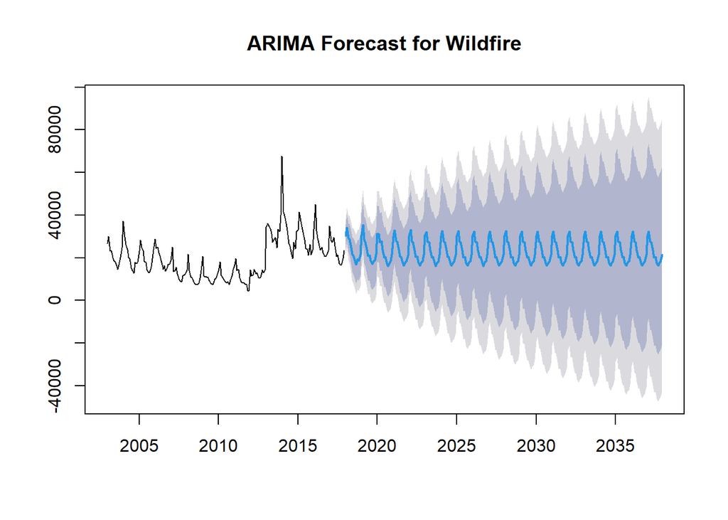

```r
# Predicción a 20 años (240 meses) para ARIMA, SARIMA, ETS y NNAR
forecast_arima_wildfire <- forecast(model_arima_wildfire, h = 240)
forecast_sarima_wildfire <- forecast(model_sarima_wildfire, h = 240)
forecast_ets_wildfire <- forecast(model_ets_wildfire, h = 240)
forecast_nnar_wildfire <- forecast(model_nnar_wildfire, h = 240)

# Visualización de los resultados
plot(forecast_arima_wildfire, main = "ARIMA Forecast for Wildfire")
```

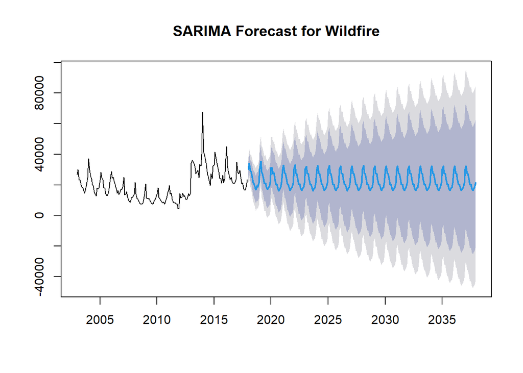

```r
plot(forecast_sarima_wildfire, main = "SARIMA Forecast for Wildfire")
```

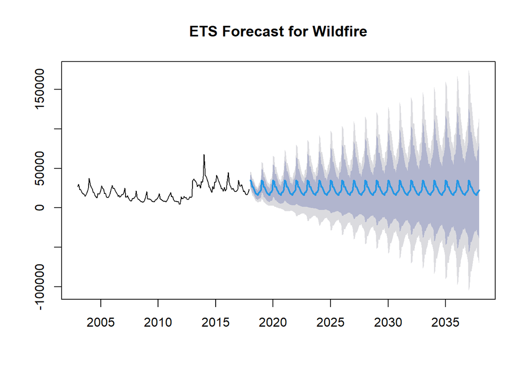

```r
plot(forecast_ets_wildfire, main = "ETS Forecast for Wildfire")
```

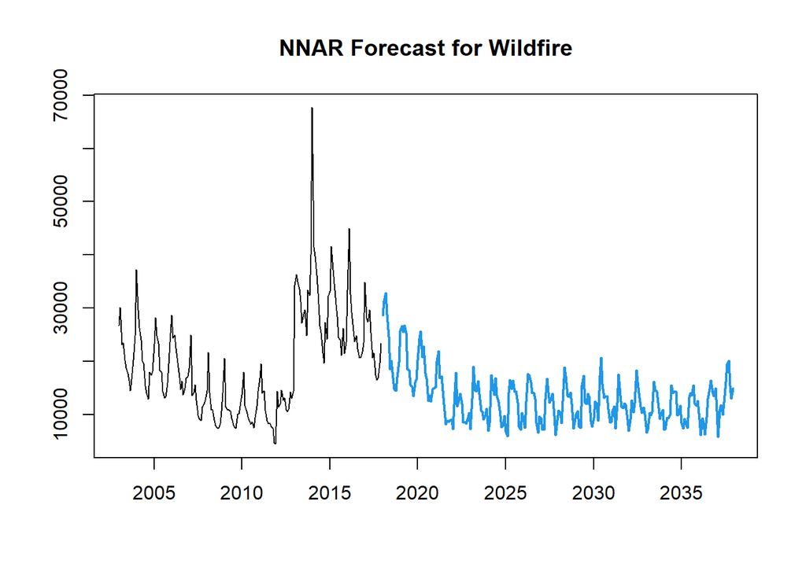

```r
plot(forecast_nnar_wildfire, main = "NNAR Forecast for Wildfire")
```

## **PREGUNTA 3: Análisis espacial de especies [3 PUNTOS]**

Seleccione una especie de planta y una especie de animal; asimismo, dos tipos de modelos de predicción (glm, gam, rf, ann, otro):

- Mosquito: *Aedes aegypti*
- Puma: *Puma concolor*
- Coati: *Nasua nasua*
- Tapir: *Tapirus terrestris*
- Jaguar: *Panthera onca*
- Palma de cera: *Ceroxylon quindiuense*
- Ceibo: *Ceiba pentandra*
- Pasiflora: *Passiflora edulis*
- Chirimoya: *Anona cherimola*

Luego realice un análisis espacial de distribución de la especie en Ecuador continental en base a los datos de presencia del GBIF (use rgbif para descargar la data). Explique el resultado y compare la diferencia entre la salida de los dos modelos. En qué regiones los modelos difieren más en la predicción?

```r
# Cargar paquetes necesarios
library(rgbif)
library(sp)
library(randomForest)
library(mgcv)
library(leaflet)
library(leaflet.extras)
```

```r
# Especificar la especie seleccionada
especie <- "Panthera onca"

# Obtener los datos de presencia del GBIF para Ecuador continental
datos_presencia <- occ_search(taxonKey = name_backbone(especie)$speciesKey, country = "EC", hasCoordinate = TRUE, limit = 10000)

# Filtrar y limpiar los datos
datos_presencia <- datos_presencia$data
datos_presencia <- na.omit(datos_presencia[, c("decimalLongitude", "decimalLatitude")])
coordenadas <- data.frame(x = datos_presencia$decimalLongitude, y = datos_presencia$decimalLatitude)

# Dividir los datos en conjuntos de entrenamiento y prueba
set.seed(123)
indices_entrenamiento <- sample(nrow(coordenadas), floor(0.7 * nrow(coordenadas)))
datos_entrenamiento <- coordenadas[indices_entrenamiento, ]
datos_prueba <- coordenadas[-indices_entrenamiento, ]

# Modelado: Bosques Aleatorios (rf)
modelo_rf <- randomForest(x ~ y, data = datos_entrenamiento, ntree = 100)

# Modelado: Generalized Additive Model (gam)
modelo_gam <- gam(y ~ s(x), data = datos_entrenamiento)

# Evaluar el desempeño de los modelos
prediccion_rf <- predict(modelo_rf, newdata = datos_prueba)
oreprediccion_gam <- predict(modelo_gam, newdata = datos_prueba)

# Comparar las predicciones de los modelos
diferencias <- abs(prediccion_rf - oreprediccion_gam)

# Agregar las coordenadas predichas al conjunto de datos de prueba
datos_prueba$pred_rf <- prediccion_rf
datos_prueba$pred_gam <- oreprediccion_gam

# Crear un nuevo conjunto de datos con coordenadas para predecir la distribución futura
set.seed(456)  # Establecer semilla para reproducibilidad
nueva_coordenadas <- data.frame(x = runif(1000, min(datos_presencia$decimalLongitude), max(datos_presencia$decimalLongitude)),
                                y = runif(1000, min(datos_presencia$decimalLatitude), max(datos_presencia$decimalLatitude)))

# Predecir la distribución futura utilizando el modelo GAM
prediccion_futura <- predict(modelo_gam, newdata = nueva_coordenadas)

# Crear mapa con la distribución actual de la especie
mapa_presencia_actual <- leaflet(data = datos_prueba) %>%
  addTiles() %>%
  addMarkers(lng = ~x, lat = ~y,
             popup = ~paste("Especie:", especie, "<br>",
                            "Predicción Bosques Aleatorios (rf):", round(pred_rf, 2), "<br>",
                            "Predicción Generalized Additive Model (gam):", round(pred_gam, 2), "<br>",
                            "Diferencia de predicción:", round(diferencias, 2)),
             label = ~especie) %>%
  hideGroup("Distribución actual")

# Crear mapa con la distribución futura de la especie
mapa_presencia_futura <- leaflet(data = nueva_coordenadas) %>%
  addTiles() %>%
  addCircleMarkers(lng = ~x, lat = ~y, radius = 5, color = "green", fillOpacity = 0.8,
                   popup = ~paste("Predicción futura:", round(prediccion_futura, 2))) %>%
  addLegend("bottomright", title = "Distribución futura", colors = "green", labels = "Predicción")

# Visualizar ambos mapass
mapa_presencia_actual
```

[interactive chart not shown]

```r
mapa_presencia_futura
```

[interactive chart not shown]

```r
# Cargar paquetes necesarios
library(rgbif)
library(sp)
library(randomForest)
library(mgcv)
library(leaflet)
library(leaflet.extras)

# Especificar la especie seleccionada
especie <- "Ceiba pentandra"

# Obtener los datos de presencia del GBIF para Ecuador continental
datos_presencia <- occ_search(taxonKey = name_backbone(especie)$speciesKey, country = "EC", hasCoordinate = TRUE, limit = 10000)

# Filtrar y limpiar los datos
datos_presencia <- datos_presencia$data
datos_presencia <- na.omit(datos_presencia[, c("decimalLongitude", "decimalLatitude")])
coordenadas <- data.frame(x = datos_presencia$decimalLongitude, y = datos_presencia$decimalLatitude)

# Dividir los datos en conjuntos de entrenamiento y prueba
set.seed(123)
indices_entrenamiento <- sample(nrow(coordenadas), floor(0.7 * nrow(coordenadas)))
datos_entrenamiento <- coordenadas[indices_entrenamiento, ]
datos_prueba <- coordenadas[-indices_entrenamiento, ]

# Modelado: Bosques Aleatorios (rf)
modelo_rf <- randomForest(x ~ y, data = datos_entrenamiento, ntree = 100)

# Modelado: Generalized Additive Model (gam)
modelo_gam <- gam(y ~ s(x), data = datos_entrenamiento)

# Evaluar el desempeño de los modelos
prediccion_rf <- predict(modelo_rf, newdata = datos_prueba)
oreprediccion_gam <- predict(modelo_gam, newdata = datos_prueba)

# Comparar las predicciones de los modelos
diferencias <- abs(prediccion_rf - oreprediccion_gam)

# Agregar las coordenadas predichas al conjunto de datos de prueba
datos_prueba$pred_rf <- prediccion_rf
datos_prueba$pred_gam <- oreprediccion_gam

# Crear un nuevo conjunto de datos con coordenadas para predecir la distribución futura
set.seed(456)  # Establecer semilla para reproducibilidad
nueva_coordenadas <- data.frame(x = runif(1000, min(datos_presencia$decimalLongitude), max(datos_presencia$decimalLongitude)),
                                y = runif(1000, min(datos_presencia$decimalLatitude), max(datos_presencia$decimalLatitude)))

# Predecir la distribución futura utilizando el modelo GAM
prediccion_futura <- predict(modelo_gam, newdata = nueva_coordenadas)

# Crear mapa con la distribución actual de la especie
mapa_presencia_actual <- leaflet(data = datos_prueba) %>%
  addTiles() %>%
  addMarkers(lng = ~x, lat = ~y,
             popup = ~paste("Especie:", especie, "<br>",
                            "Predicción Bosques Aleatorios (rf):", round(pred_rf, 2), "<br>",
                            "Predicción Generalized Additive Model (gam):", round(pred_gam, 2), "<br>",
                            "Diferencia de predicción:", round(diferencias, 2)),
             label = ~especie) %>%
  hideGroup("Distribución actual")

# Crear mapa con la distribución futura de la especie
mapa_presencia_futura <- leaflet(data = nueva_coordenadas) %>%
  addTiles() %>%
  addCircleMarkers(lng = ~x, lat = ~y, radius = 5, color = "green", fillOpacity = 0.8,
                   popup = ~paste("Predicción futura:", round(prediccion_futura, 2))) %>%
  addLegend("bottomright", title = "Distribución futura", colors = "green", labels = "Predicción")

# Visualizar ambos mapas
mapa_presencia_actual
```

[interactive chart not shown]

```r
mapa_presencia_futura
```

[interactive chart not shown]